# Statistical inference

# 1 Statistical Inference

Learning outcomes:

- to define null and alternative hypothesis
- to perform a hypothesis test using resampling
- to perform a t-test
- to understand and define sampling distribution and standard error
- to compute standard error of mean and proportions
- to compute confidence interval of mean and proportions using the normal approximation
- to compute confidence interval of mean using the t-distribution

Statistical inference is to draw conclusions regarding properties of a population based on observations of a random sample from the population.

## 1.1 Hypothesis test

To perform a hypothesis test is to evaluate a hypothesis based on a random sample.

Typicaly, the hypotheses that are tested are assumptions about properties of the population, such as proportion, mean, mean difference, variance etc.

### 1.1.1 The null and alternative hypothesis

There are two hypotheses involved in a hypothesis test, the null hypothesis, $H_0$, and the alternative hypothesis, $H_1$.

The null hypothesis is in general neutral, “no change”, “no difference between groups”, “no association”. In general we want to show that $H_0$ is false.

The alternative hypothesis expresses what the researcher is interested in “the treatment has an effect”, “there is a difference between groups”, “there is an association”. The alternative hypothesis can also be directional “the treatment has a positive effect”.

### 1.1.2 To perform a hypothesis test

1. Define $H_0$ and $H_1$
2. Select appropriate test statistic, $T$, and compute the observed value, $t_{obs}$
3. Assume that the $H_0$ is true and compute the sampling distribution of $T$.
4. Select an appropriate significance level, $\alpha$
5. Compare the observed value, $t_{obs}$, with the computed sampling distribution under $H_0$ and compute a p-value. The p-value is the probability of observing a value at least as extreme as the observed value, if $H_0$ is true.
6. Based on the p-value either accept or reject $H_0$.

**Definition 1.1** **Sampling distribution**

A sampling distribution is the distribution of a statistic of a large number of samples drawn from a specific population.

**Definition 1.2** **Null distribution**

The null distribution is a sampling distribution when the null hypothesis is true.

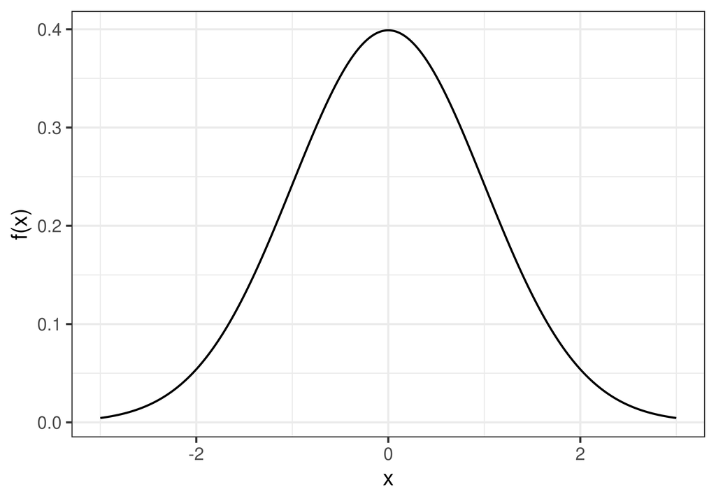

Figure 1.1: A null distribution

**Definition 1.3** **p-value**

The p-value is the probability of the observed value, or something more extreme, if the null hypothesis is true.

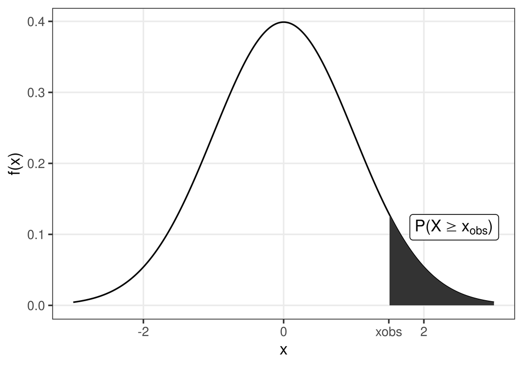

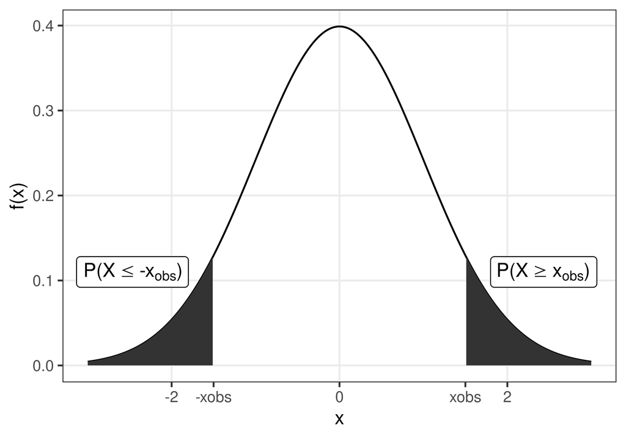

Figure 1.2: The p-value is the probability to observe $x_{obs}$ or something more extreme, if the null hypothesis is true.

### 1.1.3 Significance level and error types

|  | H0 is true | H0 is false |
| --- | --- | --- |
| Accept H0 |  | Type II error, miss |
| Reject H0 | Type I error, false alarm |  |

The significance level, $\alpha$ = P(false alarm) = P(Reject $H_0$|$H_0$ is true).

The significance level is the risk to of false alarm, i.e. to say “I have a hit”, “I found a difference”, when the the null hypothesis (“there is no difference”) is true. The risk of false alarm is controll by setting the significance level to a disired value. We do want to keep the risk of false alarm (type I error) low, but at the same time we don’t want to many missed hits (type II error).

The significance level should be set before the hypothesis test is performed. Common values to use are 0.05 or 0.01.

If the p-value is above the significance level, $H_0$ is accepted.

If the p-value is below the significance level, $H_0$ is rejected.

### 1.1.4 Hypothesis test, simulation examples

In these examples the significance level is set to 0.05.

**Example 1.1 (Simulation example)** **Pollen allergy**

Let’s assume we know that the proportion of pollen allergy in Sweden is $0.3$. We suspect that the number of pollen allergic has increased in Uppsala in the last couple of years and want to investigate this.

Observe 100 people from Uppsala, 42 of these were allergic to pollen. Is there a reason to believe that the proportion of pollen allergic in Uppsala $\pi > 0.3$?

##### Null and alternative hypotheses

$H_0:$ The proportion of pollen allergy in Uppsala is the same as in Sweden as a whole.

or expressed differently;

$$H_0:\, \pi=\pi_0$$

$$H_1:\, \pi>\pi_0$$
where $\pi$ is the unknown proportion of pollen allergy in the Uppsala population that. $\pi_0 = 0.3$ is the proportion of pollen allergy in Sweden.

##### Test statistic

Here we are interested in the proportion of pollen allergic in Uppsala. An appropriate test statistic could be the number of pollen allergic in a sample of size $n=100$, $X$. As an alternative we can use the proportion of pollen allergic in a sample of size $n$,

$$P = \frac{X}{n}$$

Let’s use $P$ as our test statistic and compute the observed value, $p_{obs}$. In our sample of 100 people from Uppsala the proportion allergic to pollen is $p=42/100=0.42$.

##### Null distribution

The sampling distribution of $P$ under $H_0$ (i.e. when the null hypothesis is true) is what we call the null distribution.

$H_0$ state that $\pi=0.3$. We can model this using an urn model as follows;

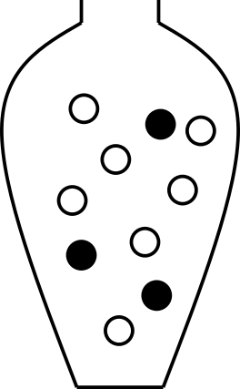

Figure 1.3: An urn model of the null hypothesis $\pi=0.3$. The black balls represent allergic and the white balls non-allergic.

Using this model, we can simulate taking a sample of size 100 many times.

```r
## Urn
rep(c(0, 1), c(7, 3))
```

```
##  [1] 0 0 0 0 0 0 0 1 1 1
```

```r
## Sample 100 times with replacement
sample(rep(c(0, 1), c(7, 3)), 100, replace=TRUE)
```

```
##   [1] 1 0 0 1 0 0 0 0 0 0 1 1 1 1 0 1 0 0 0 0 0 1 0 0 1 0 1 0 0 0 1 0 0 0 0 0 0
##  [38] 0 0 0 0 1 1 0 0 1 1 0 1 0 1 0 0 1 0 1 0 0 0 0 0 1 0 0 1 1 0 0 0 1 0 0 0 0
##  [75] 0 1 0 1 0 0 1 0 0 1 1 1 0 0 1 0 1 0 0 0 0 0 0 0 0 0
```

```r
## Compute proportion of samples that are allergic (1)
sum(sample(rep(c(0, 1), c(7, 3)), 100, replace=TRUE))/100
```

```
## [1] 0.26
```

```r
## Draw samples of size 100 and compute proporion allergic 100000 times
p <- replicate(100000, mean(sample(rep(c(0, 1), c(7, 3)), 100, replace=TRUE)))
```

Finally plot the distribution

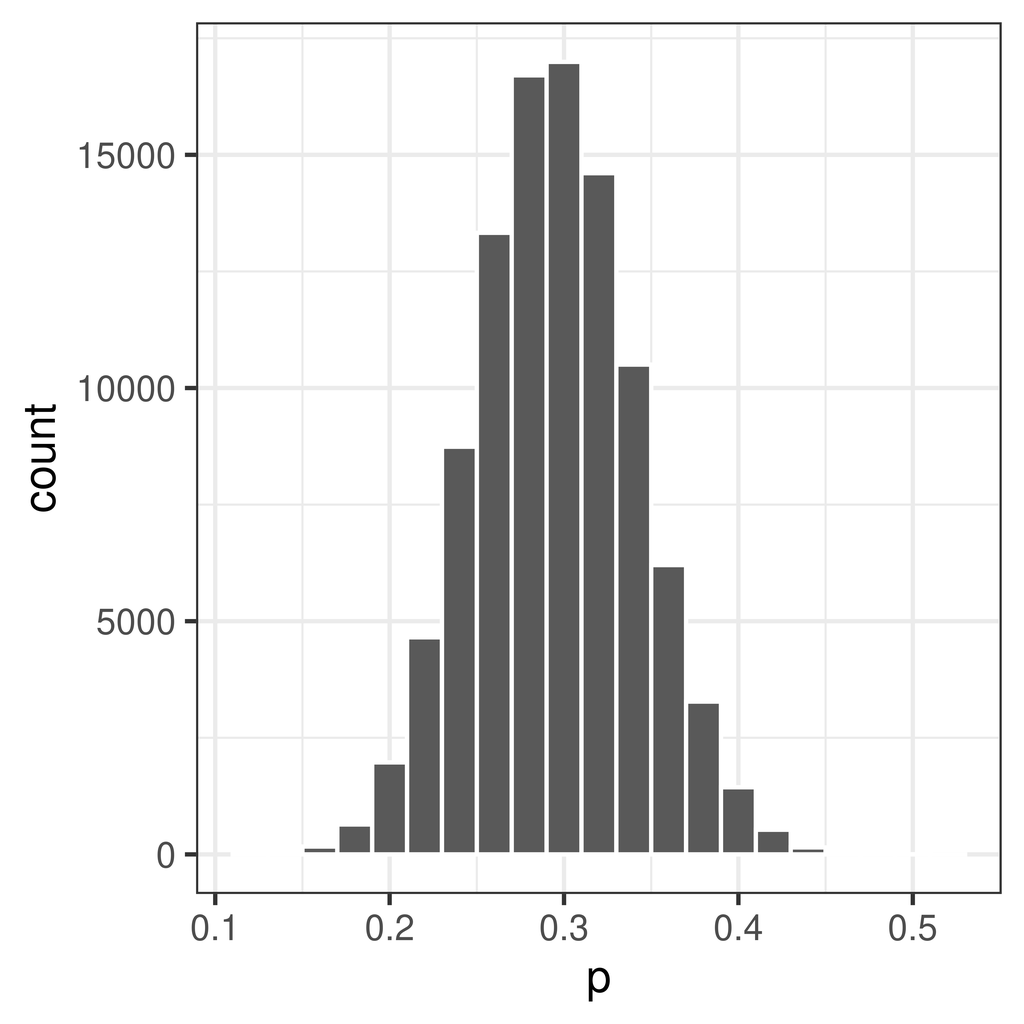

Figure 1.4: The sampling distribution.

##### Compute p-value

Compare the observed value, $p_{obs} = 0.42$ to the null distribution.

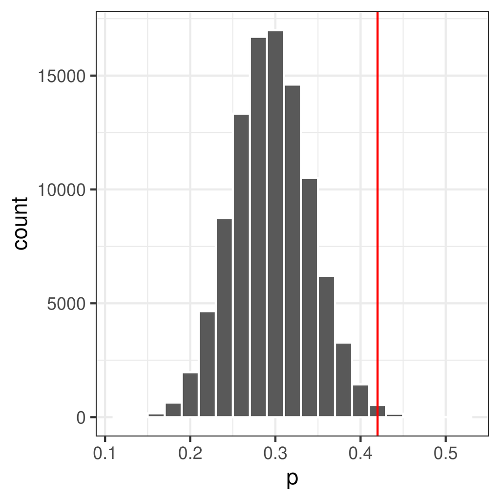

Figure 1.5: The sampling distribution. The observed value is marked by a red vertical line.

The p-value is the probability of getting the observed value or higher, if the null hypothesis is true.

Use the null distribution to calculate the p-value, $P(P \geq 0.42|H_0)$.

```r
## How many times
sum(p >= 0.42)
```

```
## [1] 739
```

```r
## p-value
sum(p >= 0.42)/length(p)
```

```
## [1] 0.0074
```

p = $P(P \geq 0.42|H_0)$ = 0.00739

##### Accept or reject $H_0$?

**Example 1.2 (Permutation test)** **Do high fat diet lead to increased body weight?**

Study setup:

1. Order 24 female mice from a lab.
2. Randomly assign 12 of the 24 mice to receive high-fat diet, the remaining 12 are controls (ordinary diet).
3. Measure body weight after one week.

##### Null and alternative hypotheses

$$\begin{aligned}
H_0: \mu_2 = \mu_1 \iff \mu_2 - \mu_1 = 0\\
H_1: \mu_2>\mu_1 \iff \mu_2-\mu_1 > 0
\end{aligned}$$

where $\mu_2$ is the (unknown) mean body weight of the high-fat mouse population and $\mu_1$ is the mean body-weight of the control mouse population.

Studied population: Female mice that can be ordered from a lab.

##### Test statistic

Here we are interested in the mean difference between high-fat and control mice.

Mean weight of 12 (randomly selected) mice on ordinary diet, $\bar X_1$. $E[\bar X_1] = E[X_1] = \mu_1$

Mean weight of 12 (randomly selected) mice on high-fat diet, $\bar X_2$. $E[\bar X_2] = E[X_2] = \mu_2$

The mean difference is also a random variable: $D = \bar X_2 - \bar X_1$

The observed values, mouse weights in grams, are summarized below;

| high-fat | 25 | 30 | 23 | 18 | 31 | 24 | 39 | 26 | 36 | 29 | 23 | 32 |
| --- | --- | --- | --- | --- | --- | --- | --- | --- | --- | --- | --- | --- |
| ordinary | 27 | 25 | 22 | 23 | 25 | 37 | 24 | 26 | 21 | 26 | 30 | 24 |

Mean weight of control mice (ordinary diet): $\bar x_1 = 25.83$

Mean weight of mice on high-fat diet: $\bar x_2 = 28.00$

Difference in mean weights: $d_{obs} = \bar x_2 - \bar x_1 = 2.1667$

##### Null distribution

If high-fat diet has no effect, i.e. if $H_0$ was true, the result would be as if all mice were given the same diet. What can we expect if all mice are fed with the same type of food?

This can be accomplished using permutation

The 24 mice were initially from the same population, depending on how the mice are randomly assigned to high-fat and normal group, the mean weights would differ, even if the two groups were treated the same.

Assume $H_0$ is true, i.e. assume all mice are equivalent and

1. Randomly reassign 12 of the 24 mice to ‘high-fat’ and the remaining 12 to ‘control’.
2. Compute difference in mean weights

If we repeat 1-2 many times we get the sampling distribution when $H_0$ is true, the so called null distribution, of difference in mean weights.

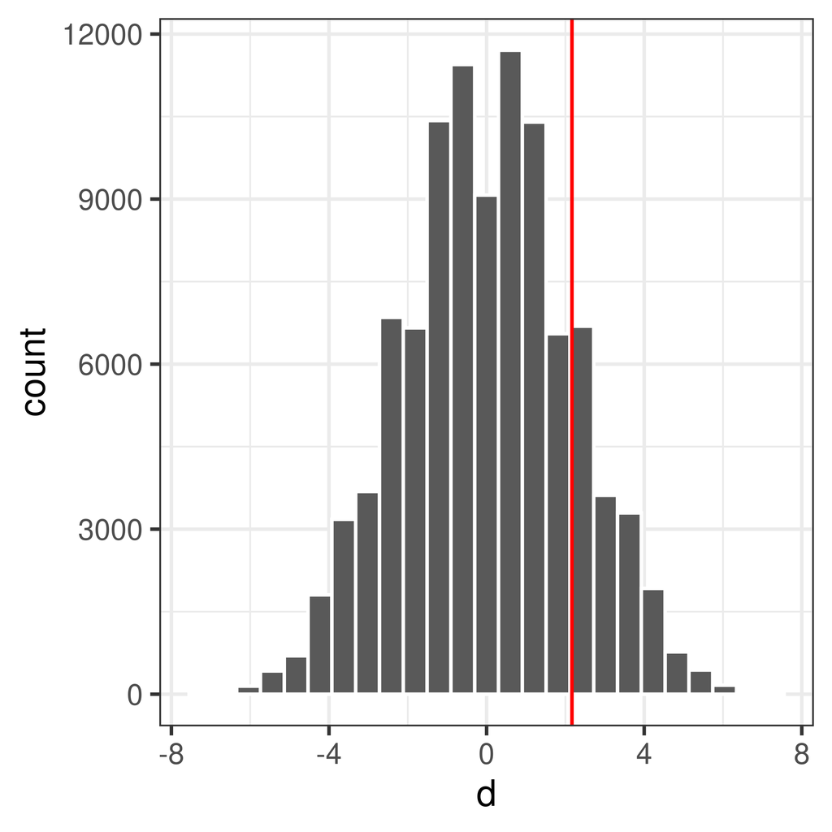

##### Compute p-value

What is the probability to get an at least as extreme mean difference as our observed value, $d_{obs}$, if $H_0$ was true?

$P(X_2 - X_2 d_{obs} | H_0) = $0.169

Conclusion?

## 1.2 Parametric distributions

In previous chapters we have computed the sampling distribution using resampling techniques to be able to perform hypothesis tests or compute interval estimates. If the null distribution was already known (or could be computed based on a few assumptions) resampling would not be necessary.

We can follow the same steps as before to perform a hypothesis test:

1. Define $H_0$ and $H_1$
2. Select appropriate test statistic, $T$, and compute the observed value, $t_{obs}$
3. Assume that the $H_0$ and derive the null distribution of the test statistic based on appropriate assumptions.
4. Select an appropriate significance level, $\alpha$
5. Compare the observed value, $t_{obs}$, with the null distribution and compute a p-value. The p-value is the probability of observing a value at least as extreme as the observed value, if $H_0$ is true.
6. Based on the p-value either accept or reject $H_0$.

### 1.2.1 One sample, proportions

**Example 1.3** **Let’s get back to the pollen example!**

Assume that the proportion of pollen allergy in Sweden is known to be $0.3$. Observe 100 people from Uppsala, 42 of these were allergic to pollen. Is there a reason to believe that the proportion of pollen allergic in Uppsala $\pi > 0.3$?

**Theorem 1.1** The sum of $n$ independent and equally distributed random variables is normally distributed, if $n$ is large enough.

As a result of the central limit theorem, the distribution of number or proportion of allergic individuals in a sample of size $n$ is approximately normal. At least if the sample is large enough. A rule of thumb is that the sample size should be $n>30$.

Here, the sample size is 100!

The normal distribution has two parameters, mean and standard deviation.

From the binomial distribution we know that $E[X] = \pi$ and $var(X) = n\pi(1-\pi)$. Hence $E[P] = \pi$ and $var(P) = \frac{\pi(1-\pi)}{n}$.

The standard error is thus

$$SE=\sqrt{\frac{\pi(1-\pi)}{n}}$$

When the null hypothesis is true $\pi$ is known and $\pi=0.3$.

Actually these calculations are true in general when a proportion in one sample is compared to a known value.

$$H_0: \pi=\pi_0 \\
H_1: \pi>\pi_0$$

Ather potential alternative hypothesis are $H_1: \pi<\pi_0$ or $H_1:\pi \neq \pi_0$, but in this particular example we are only interested in the alternative that $\pi > \pi_0$.

If $H_0$ is true $\pi=\pi_0$ and

$$P \sim N\left(\pi_0, \sqrt{\frac{\pi_0(1-\pi_0)}{n}}\right)$$
An appropriate test statistic is

$$Z = \frac{P-\pi_0}{\sqrt{\frac{\pi_0(1-\pi_0)}{n}}}$$

$Z \in N(0,1)$ which makes probabilities easy to compute.

Back to our example, replace $P$ with our observed value $p=0.42$ and $\pi_0=0.3$ and compute our observed

$$Z_{obs} = \frac{0.42-0.3}{\sqrt{\frac{0.3(1-0.3)}{100}}} = 2.62$$

The p-value is the probability of the observed value, or something more extreme, if the null hypothesis is true. If the computed probability is below $\alpha=0.05$ our significance threshold, $H_0$ will be rejected.

$$p = P(P>\pi_0) = P(Z>Z_{obs}) = P(Z>2.62) = 1 - P(Z \leq 2.62) = [table] = 1 - 0.996 = 0.0044$$

As 0.0044<0.05 we reject $H_0$ and conclude that there is reason to believe that the proportion of allergic in Uppsala is greater than 0.3.

### 1.2.2 One sample, mean

A one sample test of means compares the mean of a sample to a prespecified value.

For example, we might know that the weight of a mouse on normal diet is normally distributed with mean 24.0 g and standard deviation 3 g and want to compare the weight of a sample of 10 mice on high-fat diet to the known mean value for mice on normal diet.

The hypotheses:

$$H_0: \mu = \mu_0 \\
H_1: \mu \neq \mu_0$$

The alternative hypothesis, $H_1,$ above is for the two sided hypothesis test. Other options are the one sided $H_1$; $H_1: \mu > \mu_0$ or $H_1: \mu < \mu_0$.

If
$$X \sim N(\mu, \sigma)$$
(this could for example be the weight of a mouse on high-fat diet) then the sample mean
$$\bar X \sim N\left(\mu, \frac{\sigma}{\sqrt{n}}\right).$$

If $\sigma$ is known the test statistic

$$Z = \frac{\bar X - \mu}{\frac{\sigma}{\sqrt{n}}}$$
is normally distributed, $\sim N(0,1)$.

For small $n$ and unknown $\sigma$, the test statistic

$$t = \frac{\bar X - \mu}{\frac{s}{\sqrt{n}}}$$

is t-distributed with $df=n-1$ degrees of freedom.

### 1.2.3 Two samples, proportions

$$H_0: \pi_1 - \pi_2 = 0\\
H_1: \pi_1 - \pi_2 \neq 0$$

Alternatively, a one sided alternative hypothesis can be used; $H_1: \pi_1 - \pi_2 >0$ or $H_1: \pi_1 - \pi_2 < 0$.

Test statistic

$$Z = \frac{P_1 - P_2}{\sqrt{P(1-P)\left (\frac{1}{n_1} + \frac{1}{n_2}\right)}}$$

where $P$ is the proportion in the merged sample of size $n_1 + n_2$. $Z \in N(0,1)$ and p-value can be computed using the standard normal distribution.

### 1.2.4 Two samples, mean

A two sample test of means is used to determine if two population means are equal.

Two independent samples are collected (one from each population) and the means are compared. Can for example be used to determine if a treatment group is different compared to a control group, in terms of the mean of a property of interest.

The null hypothesis;

$$H_0: \mu_2 = \mu_1$$
The alternative hypothesis can either be two sided

$$H_1: \mu_2 \neq \mu_1$$
or one sided

$$H_1: \mu_2 > \mu_1$$
or

$$H_1: \mu_2 < \mu_1$$

Assume that observations from both populations are normally distributed;

$$\begin{aligned}
X_1 \sim N(\mu_1, \sigma_1) \\
X_2 \sim N(\mu_2, \sigma_2)
\end{aligned}$$
Then it follows that the sample means will also be normally distributed;

$$\begin{aligned}
\bar X_1 \sim N(\mu_1, \sigma_1/\sqrt{n_1}) \\
\bar X_2 \sim N(\mu_2, \sigma_2/\sqrt{n_2})
\end{aligned}$$

The mean difference $D = \bar X_2 - \bar X_1$ is thus also normally distributed:

$$D = \bar X_2 - \bar X_1 = N\left(\mu_2-\mu_1, \sqrt{\frac{\sigma_2^2}{n_2} + \frac{\sigma_1^2}{n_1}}\right)$$

If $H_0$ is true:
$$D = \bar X_2 - \bar X_1 = N\left(0, \sqrt{\frac{\sigma_2^2}{n_2} + \frac{\sigma_1^2}{n_1}}\right)$$

The test statistic:
$$Z = \frac{\bar X_2 - \bar X_1}{\sqrt{\frac{\sigma_2^2}{n_2} + \frac{\sigma_1^2}{n_1}}}$$
is standard normal, i.e. $Z \sim N(0,1)$.

However, note that the test statistic require the standard deviations $\sigma_1$ and $\sigma_2$ to be known.

What if the population standard deviations are not known?

If the sample sizes are large, we can replace the known standard deviations with our sample standard deviations and according to the central limit theorem assume that

$$Z = \frac{\bar X_2 - \bar X_1}{\sqrt{\frac{s_2^2}{n_2} + \frac{s_1^2}{n_1}}} \sim N(0,1)$$

and proceed as before.

For small sample sizes the test statistic will be t-distributed.

$$t = \frac{\bar X_2 - \bar X_1}{\sqrt{\frac{s_2^2}{n_2} + \frac{s_1^2}{n_1}}}$$

For small sample sizes we can use Student’s t-test, which requires us to assume that $X_1$ and $X_2$ both are normally distributed and have equal variances. With these assumptions we can compute the pooled variance

$$s_p^2 = \frac{(n_1-1)s_1^2 + (n_2-1)s_2^2}{n_1+n_2-2}$$

and the test statistic

$$t = \frac{\bar X_1 - \bar X_2}{\sqrt{s_p^2(\frac{1}{n_1} + \frac{1}{n_2})}}$$

$t$ is t-distributed with $n_1+n_2-2$ degrees of freedom.

The t-test is implemented in R, e.g. in the function `t.test` in the R-package `stats`, both Student’s t-test with equal variances and Welch’s t-test with unequal variances.

### 1.2.5 Variance

The test of equal variance in two groups is based on the null hypothesis

$$H_0: \sigma_1^2 = \sigma_2^2$$

If the two samples both come from two populations with normal distributions, the sample variances

$$S_1^2 = \frac{1}{n_1-1} \sum_{i=1}^{n_1} (X_{1i}-\bar X_1)^2\\
S_2^2 = \frac{1}{n_2-1} \sum_{i=1}^{n_2} (X_{2i}-\bar X_2)^2$$

It can be shown that $\frac{(n_1-1)S_1^2}{\sigma_1^2} \sim \chi^2(n_1-1)$ and $\frac{(n_2-1)S_2^2}{\sigma_2^2} \sim \chi^2(n_2-1)$.

Hence, the test statistic for comparing the variances of two groups

$$F = \frac{S_1^2}{S_2^2}$$
is $F$-distributed with $n_1-1$ and $n_2-1$ degrees of freedom.

In R a test of equal variances can be performred using the function `var.test`.

### 1.2.6 Exercises

**Exercise 1.1** The hemoglobin value (Hb) in women is on average 140 g/L. You observe the following Hb values in a set of five men: 154, 140, 147, 162, 172. Assume that Hb is normally distributed. Is there a reason to believe that the mean Hb value in men differ from that in women?

**Exercise 1.2** In order to study the effect of high-fat diet 12 mice are fed normal diet (control group) and 12 mice are fed high-fat diet. After a couple of weeks the mouse weights in gram are recorded;

| high-fat | 25 | 30 | 23 | 18 | 31 | 24 | 39 | 26 | 36 | 29 | 23 | 32 |
| --- | --- | --- | --- | --- | --- | --- | --- | --- | --- | --- | --- | --- |
| ordinary | 27 | 25 | 22 | 23 | 25 | 37 | 24 | 26 | 21 | 26 | 30 | 24 |

Does high fat diet increase body weight in mice?

1. Assume equal variances.

```r
# Student's t-test with pooled variances
t.test(xHF, xN, var.equal=TRUE, alternative="greater")
```

2. Don’t assume equal variances.

```r
# Unequal variances with Welch approximation to the degrees of freedom (the default)
t.test(xHF, xN, var.equal=FALSE, alternative="greater")
```

## 1.3 Point and interval estimates

As seen in previous chapter, the sample proportion or mean is an unbiased estimate of the population values. When we only have a sample, the sample estimate will be our best guess of the population value, but it will not be without error.

If we are interested in how large proportion of the Uppsala population is allergic to pollen, we can investigate this by studying a random sample. Randomly select 100 persons in Uppsala. It is important to actually sample randomly, ideally every individual should have the same probability of being sampled.

### 1.3.1 Bootstrap interval

Using bootstrap we can sample with replacement from our sample to estimate the uncertainty.

Bootstrap is to use the data we have (our sample) and sample repeatedly with replacement from this data.

Put the entire sample in an urn!

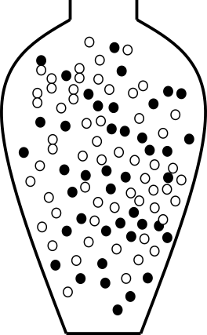

Sample from the urn with replacement to compute the bootstrap distribution.

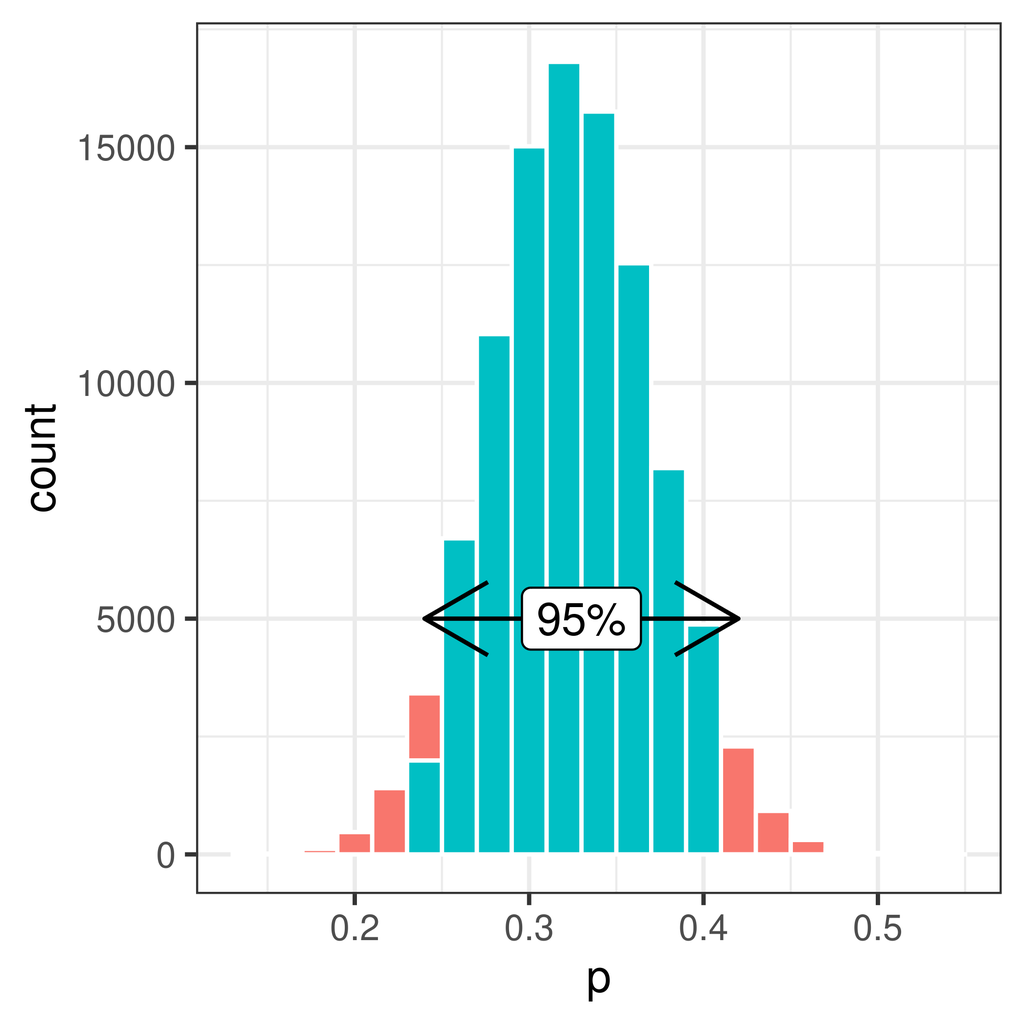

Using the bootstrap distribution the uncertainty of our estimate of $\pi$ can be estimated.

The 95% bootstrap interval is [0.24, 0.42].

The bootstrap is very useful if you do not know the distribution of our sampled propery. But in our example we actually do.

### 1.3.2 Confidence interval

A confidence interval is a type of interval estimate associated with a confidence level.

#### 1.3.2.1 Confidence interval of proportions

Remember that we can use the central limit theorem to show that

$$P \sim N\left(\pi, SE\right) \iff P \sim \left(\pi, \sqrt{\frac{\pi(1-\pi)}{n}}\right)$$

It follows that

$$Z = \frac{P - \pi}{SE} \sim N(0,1)$$
Based on what we know of the standard normal distribution, we can compute an interval around the population property $\pi$ such that the probability that a sample property $p$ fall within this interval is $1-\alpha$.

$$P(-z < \frac{P - \pi}{SE} < z) = 1 - \alpha$$
For a 95% confidence interval z=1.96 (from a table of the standard normal distribution). Other confidence levels of interest include 90% (z=1.64) and 99% (z=2.58).

$$P\left(-z < \frac{P-\pi}{SE}<z\right) = \left(-z < Z <z\right) = 1-\alpha$$
We can rewrite this to

$$P\left(\pi-z SE < P < \pi + z SE\right) = 1-\alpha$$
in other words sample fraction $p$ will fall between $\pi \pm 1.96 SE$ with 95% probability.

The equation can also be rewritten to
$$P\left(P-z SE < \pi < P + z SE\right) = 1 - \alpha$$
The observed confidence interval is what we get when we replace the random variable $P$ with our observed fraction,

$$p-z SE < \pi < p + z SE$$
$$\pi = p \pm z SE = p \pm z \sqrt{\frac{p(1-p)}{n}}$$
The 95% confidence interval
$$\pi = p \pm 1.96 \sqrt{\frac{p(1-p)}{n}}$$

A 95% confidence interval will have 95% chance to cover the true value.

[figure not shown]

Back to our example of proportion pollen allergic in Uppsala. $p=0.33$ and $SE=\sqrt{\frac{p(1-p)}{n}} = 0.047$.

Hence, the 95% confidence interval is
$$\pi = 0.33 \pm 1.96 * 0.05 = 0.33 \pm 0.092$$
or
$$(0.33-0.092, 0.33+0.092) = (0.24, 0.42)$$

**Exercise 1.3** a) How can we get a narrower confidence interval? b) Here we computed a 95% interval, what if we want a 90% confidence interval? c) or a 99% confidence interval?

##### 1.3.2.1.1 Confidence interval of mean

The confidence interval of mean can be derived similarly.

The mean of a sample of $n$ independent and identically normal distributed observations $X_i$ is normally distributed;

$$\bar X \sim N(\mu, \frac{\sigma}{\sqrt{n}})$$

If $\sigma$ is unknown the statistic

$$\frac{\bar X - \mu}{\frac{\sigma}{\sqrt{n}}} \sim t(n-1)$$
is t-distributed with $n-1$ degrees of freedom.

It follows that

$$\begin{aligned}
P\left(-t < \frac{\bar X - \mu}{\frac{\sigma}{\sqrt{n}}} < t\right) = 1 - \alpha \iff \\
P\left(\bar X - t \frac{\sigma}{\sqrt{n}} < \mu < \bar X + t \frac{\sigma}{\sqrt{n}}\right) = 1 - \alpha
\end{aligned}$$

The confidence interval with confidence level $1-\alpha$ is thus;

$$\mu = \bar x \pm t \frac{s}{\sqrt{n}}$$

For a 95% confidence interval and $n=5$ $t$ is 2.7764.

The $t$ values for different values of $\alpha$ and degrees of freedom are tabulated and can be computed in R using the function `qt`.

```r
n=5
alpha = 0.05
## t value
qt(1-alpha/2, df=n-1)
```

```
## [1] 2.776
```

**Exercise 1.4** You measure the Hb value in 10 50 year old men and get the following observations; 145, 165, 134, 167, 158, 176, 156, 189, 143, 123. Compute a 95% confidence interval for the mean Hb value.

## 1.4 Multiple testing

### 1.4.1 Error types

|  | Accept H0 | Reject H0 |
| --- | --- | --- |
| H0 is true |  | Type I error, false alarm |
| H0 is false | Type II error, miss |  |

|  | Accept H0 | Reject H0 |
| --- | --- | --- |
| H0 is true | TN | FP |
| H0 is false | FN | TP |

Significance level

$$P(\mbox{reject }\,H_0 | H_0 \,\mbox{is true}) = P(\mbox{type I error}) = \alpha$$

Statistical power

$$P(\mbox{reject } H_0 | H_1 \mbox{ is true}) = P(\mbox{reject } H_0 | H_0 \mbox{ is false}) = 1 - P(\mbox{type II error})$$

#### 1.4.1.1 Perform one test:

- P(One type I error) = $\alpha$
  - P(No type I error) = $1 - \alpha$

#### 1.4.1.2 Perform $m$ independent tests:

- P(No type I errors in $m$ tests) = $(1 - \alpha)^m$
  - P(At least one type I error in $m$ tests) = $1 - (1 - \alpha)^m$

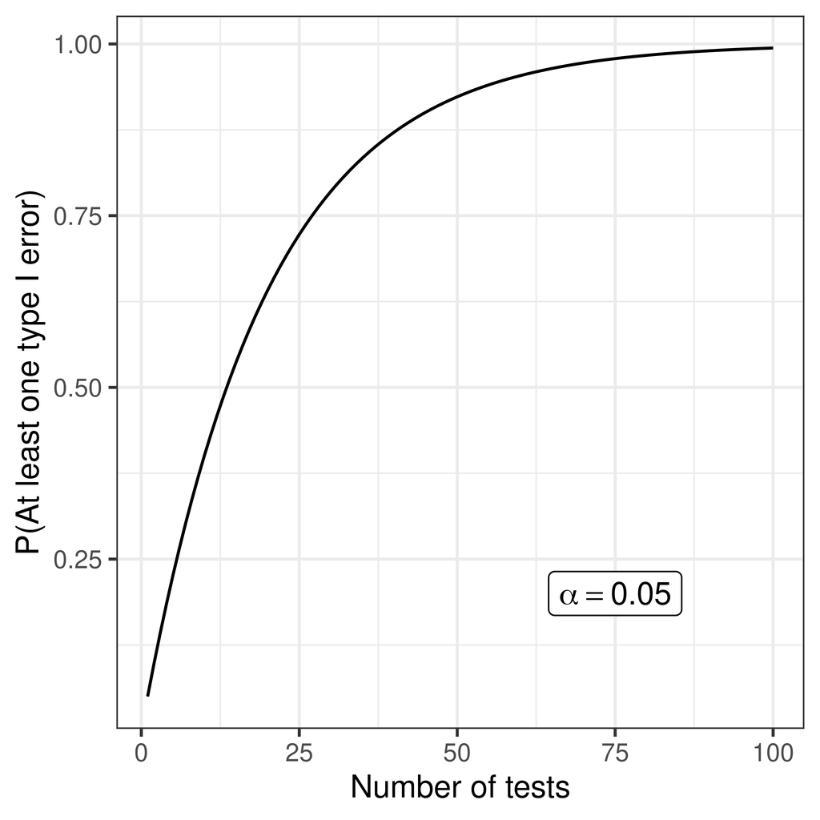

- FWER: family-wise error rate, probability of one or more false positive, e.g. Bonferroni, Holm
  - FDR: false discovery rate, proportion of false positives among hits, e.g. Benjamini-Hochberg, Storey

### 1.4.2 Bonferroni correction

To achieve a family-wise error rate of $\leq \alpha$ when performing $m$ tests, declare significance and reject the null hypothesis for any test with $p \leq \alpha/m$.

Objections: too conservative

### 1.4.3 Benjamini-Hochbergs FDR

|  | H0 is true | H0 is false |
| --- | --- | --- |
| Accept H0 | TN | FN |
| Reject H0 | FP | TP |

The false discovery rate is the proportion of false positives among ‘hits’, i.e. $\frac{FP}{TP+FP}$.

Benjamini-Hochberg’s method control the FDR level, $\gamma$, when performing $m$ *independent* tests, as follows:

1. Sort the p-values $p_1 \leq p_2 \leq \dots \leq p_m$.
2. Find the maximum $j$ such that $p_j \leq \gamma \frac{j}{m}$.
3. Declare significance for all tests $1, 2, \dots, j$.

### 1.4.4 ‘Adjusted’ p-values

Sometimes an adjusted significance threshold is not reported, but instead ‘adjusted’ p-values are reported.

- Using Bonferroni’s method the adjusted p-values are:

  $\tilde p_i = \min(m p_i, 1)$.

A feature’s adjusted p-value represents the smallest FWER at which the null hypothesis will be rejected, i.e. the feature will be deemed significant.

- Benjamini-Hochberg’s ‘adjusted’ p-values are called $q$-values:

  $q_i = \min(\frac{m}{i} p_i, 1)$

  A feature’s $q$-value can be interpreted as the lowest FDR at which the corresponding null hypothesis will be rejected, i.e. the feature will be deemed significant.

### Example, 10000 independent tests (e.g. genes)

| p-value | adj p (Bonferroni) | q-value (B-H) |
| --- | --- | --- |
| 1.7e-08 | 0.0002 | 0.0002 |
| 5.8e-08 | 0.0006 | 0.0003 |
| 3.4e-07 | 0.0034 | 0.0011 |
| 9.1e-07 | 0.0091 | 0.0020 |
| 1e-06 | 0.0100 | 0.0020 |
| 2.4e-06 | 0.0240 | 0.0040 |
| 2.3e-05 | 0.2300 | 0.0329 |
| 3.6e-05 | 0.3600 | 0.0450 |
| 0.00022 | 1.0000 | 0.2300 |
| 0.00023 | 1.0000 | 0.2300 |
| 0.00073 | 1.0000 | 0.6636 |
| 0.0032 | 1.0000 | 1.0000 |
| 0.0045 | 1.0000 | 1.0000 |
| 0.0087 | 1.0000 | 1.0000 |
| 0.0089 | 1.0000 | 1.0000 |
| 0.012 | 1.0000 | 1.0000 |
| 0.014 | 1.0000 | 1.0000 |
| 0.045 | 1.0000 | 1.0000 |
| 0.08 | 1.0000 | 1.0000 |
| 0.23 | 1.0000 | 1.0000 |